# Week 7 Assignment

Naim Sejtanic

```r
library(dplyr)
library(ggplot2)
library(tseries)
library(urca)
library(vars)
```

# Analyzing commodity time series data using the commodity.csv

```r
#Import Commodity Data and add natural logarithm of each commodity
commodity_data <- read.csv("commodity.csv", header =TRUE)
commodity_data$log_copper <- log(commodity_data$copper)
commodity_data$log_cotton <- log(commodity_data$cotton)
commodity_data$log_maize <- log(commodity_data$maize)
commodity_data$log_sugar <- log(commodity_data$sugar)
commodity_data$log_wheat <- log(commodity_data$wheat)
commodity_data$log_wool <- log(commodity_data$wool)
commodity_data$log_zinc <- log(commodity_data$zinc)
log_data <- commodity_data[,9:15]
#Calculate first difference of commodity prices
diff_copper <- diff(commodity_data$copper)
diff_cotton <- diff(commodity_data$cotton)
diff_maize <- diff(commodity_data$maize)
diff_sugar <- diff(commodity_data$sugar)
diff_wheat <- diff(commodity_data$wheat)
diff_wool <- diff(commodity_data$wool)
diff_zinc <- diff(commodity_data$zinc)
diff_data <- data.frame(diff_copper,diff_cotton,diff_maize,diff_sugar,diff_wheat,diff_wool,diff_zinc)
#Calculate log returns of commodity prices
copper_return <- diff(log(commodity_data$copper))
cotton_return <- diff(log(commodity_data$cotton))
maize_return <- diff(log(commodity_data$maize))
sugar_return <- diff(log(commodity_data$sugar))
wheat_return <- diff(log(commodity_data$wheat))
wool_return <- diff(log(commodity_data$wool))
zinc_return <- diff(log(commodity_data$zinc))
return_data <- data.frame(copper_return,cotton_return,maize_return,sugar_return,wheat_return,wool_return,zinc_return)
```

## The plot for the log commodity prices seems to be non-stationary for all commodities, as there is an observable slight upward trend for each commodity over time.

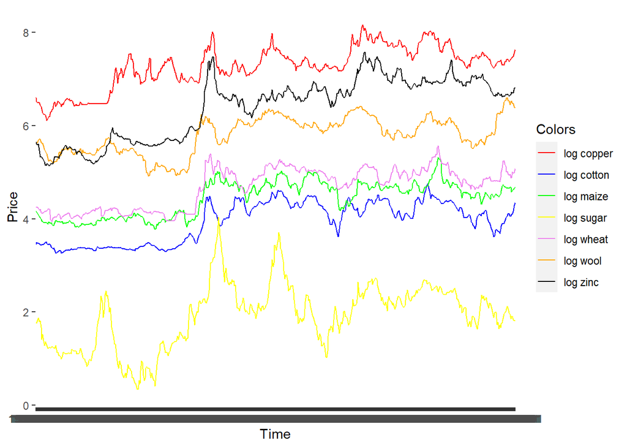

## By glancing at the graphs, most of the first differences of each commodity seem to possibly show increasing variance over time, especially after the first 200 observations, which would seem to indicate non-stationairity. However, sugar and copper seem to be less obvious and could be stationary.

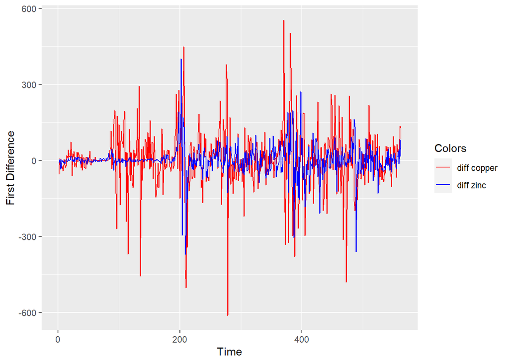

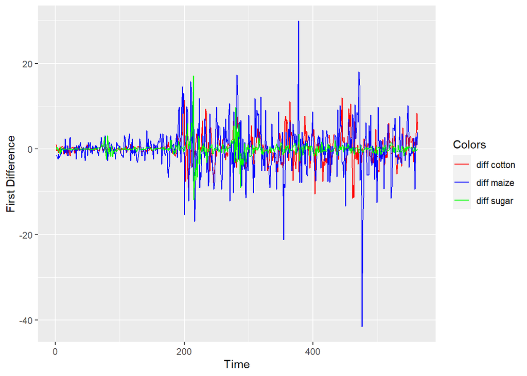

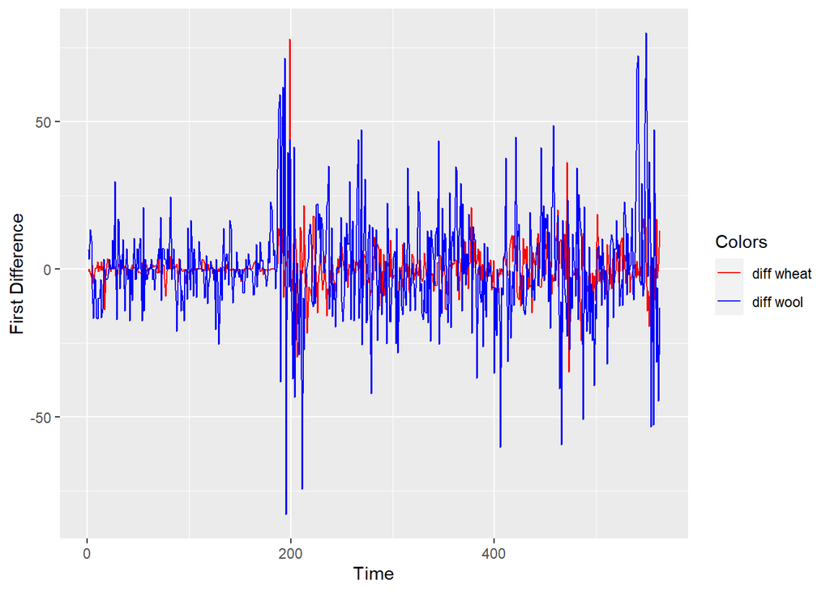

## A quick glance at the graphs of the log returns of each commodity price doesn’t seem to indicate any trends or increasing variances, which seems to indicate to all of them being stationary.

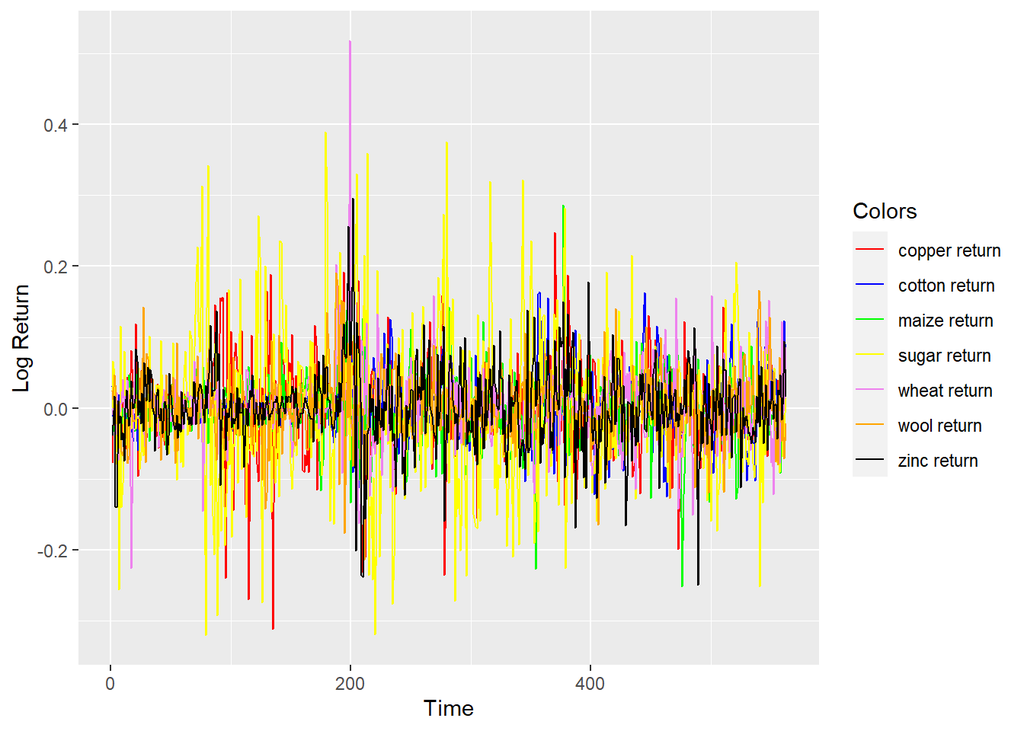

## We can see from observing each of the commodity’s DF test result’s t-values, that none of them are negative enough to reject, even the 10 percent rejection level, which suggests that we can not reject the null-hypothesis of non-stationarity.

```r
DFtest_copper <- ur.df(commodity_data$log_copper, type = "drift", lags=0)
print(summary(DFtest_copper))
```

```
##
## ###############################################
## # Augmented Dickey-Fuller Test Unit Root Test #
## ###############################################
##
## Test regression drift
##
##
## Call:
## lm(formula = z.diff ~ z.lag.1 + 1)
##
## Residuals:
##       Min        1Q    Median        3Q       Max
## -0.312043 -0.035484 -0.000795  0.032256  0.249719
##
## Coefficients:
##              Estimate Std. Error t value Pr(>|t|)
## (Intercept)  0.085105   0.043398   1.961   0.0504 .
## z.lag.1     -0.011456   0.005959  -1.922   0.0551 .
## ---
## Signif. codes:  0 '***' 0.001 '**' 0.01 '*' 0.05 '.' 0.1 ' ' 1
##
## Residual standard error: 0.06332 on 560 degrees of freedom
## Multiple R-squared:  0.006556,   Adjusted R-squared:  0.004782
## F-statistic: 3.696 on 1 and 560 DF,  p-value: 0.05506
##
##
## Value of test-statistic is: -1.9224 2.0839
##
## Critical values for test statistics:
##       1pct  5pct 10pct
## tau2 -3.43 -2.86 -2.57
## phi1  6.43  4.59  3.78
```

```r
DFtest_cotton <- ur.df(commodity_data$log_cotton, type = "drift", lags=0)
print(summary(DFtest_cotton))
```

```r
DFtest_maize <- ur.df(commodity_data$log_maize, type = "drift", lags=0)
print(summary(DFtest_maize))
```

```r
DFtest_sugar <- ur.df(commodity_data$log_sugar, type = "drift", lags=0)
print(summary(DFtest_sugar))
```

```r
DFtest_wheat <- ur.df(commodity_data$log_wheat, type = "drift", lags=0)
print(summary(DFtest_wheat))
```

```r
DFtest_wool <- ur.df(commodity_data$log_wool, type = "drift", lags=0)
print(summary(DFtest_wool))
```

```r
DFtest_zinc <- ur.df(commodity_data$log_zinc, type = "drift", lags=0)
print(summary(DFtest_zinc))
```

## Adding 2 lags we are able to see slightly more evidence towards rejection, as the t-values become more negative, however, we are still unable to reject the null of non-stationarity at any of the significance levels as they are still not negative enough.

```r
DFtest_copper2 <- ur.df(commodity_data$log_copper, type = "drift", lags=2)
print(summary(DFtest_copper2))
```

```
##
## ###############################################
## # Augmented Dickey-Fuller Test Unit Root Test #
## ###############################################
##
## Test regression drift
##
##
## Call:
## lm(formula = z.diff ~ z.lag.1 + 1 + z.diff.lag)
##
## Residuals:
##       Min        1Q    Median        3Q       Max
## -0.282946 -0.031595 -0.004096  0.032917  0.228729
##
## Coefficients:
##              Estimate Std. Error t value Pr(>|t|)
## (Intercept)  0.095452   0.041162   2.319 0.020762 *
## z.lag.1     -0.012908   0.005651  -2.284 0.022747 *
## z.diff.lag1  0.362900   0.041698   8.703  < 2e-16 ***
## z.diff.lag2 -0.151466   0.041840  -3.620 0.000321 ***
## ---
## Signif. codes:  0 '***' 0.001 '**' 0.01 '*' 0.05 '.' 0.1 ' ' 1
##
## Residual standard error: 0.05945 on 556 degrees of freedom
## Multiple R-squared:  0.1278, Adjusted R-squared:  0.1231
## F-statistic: 27.16 on 3 and 556 DF,  p-value: < 2.2e-16
##
##
## Value of test-statistic is: -2.284 2.8138
##
## Critical values for test statistics:
##       1pct  5pct 10pct
## tau2 -3.43 -2.86 -2.57
## phi1  6.43  4.59  3.78
```

```r
DFtest_cotton2 <- ur.df(commodity_data$log_cotton, type = "drift", lags=2)
print(summary(DFtest_cotton2))
```

```r
DFtest_maize2 <- ur.df(commodity_data$log_maize, type = "drift", lags=2)
print(summary(DFtest_maize2))
```

```r
DFtest_sugar2 <- ur.df(commodity_data$log_sugar, type = "drift", lags=2)
print(summary(DFtest_sugar2))
```

```r
DFtest_wheat2 <- ur.df(commodity_data$log_wheat, type = "drift", lags=2)
print(summary(DFtest_wheat2))
```

```r
DFtest_wool2 <- ur.df(commodity_data$log_wool, type = "drift", lags=2)
print(summary(DFtest_wool))
```

```r
DFtest_zinc2 <- ur.df(commodity_data$log_zinc, type = "drift", lags=2)
print(summary(DFtest_zinc2))
```

## Using the PP test we are still unable to reject at any of the significance levels for any of the commodity log prices.

```r
pp_copper <- ur.pp(commodity_data$log_copper, type = "Z-tau", model="constant", lags="short")
print(summary(pp_copper))
```

```
##
## ##################################
## # Phillips-Perron Unit Root Test #
## ##################################
##
## Test regression with intercept
##
##
## Call:
## lm(formula = y ~ y.l1)
##
## Residuals:
##       Min        1Q    Median        3Q       Max
## -0.312043 -0.035484 -0.000795  0.032256  0.249719
##
## Coefficients:
##             Estimate Std. Error t value Pr(>|t|)
## (Intercept) 0.085105   0.043398   1.961   0.0504 .
## y.l1        0.988544   0.005959 165.893   <2e-16 ***
## ---
## Signif. codes:  0 '***' 0.001 '**' 0.01 '*' 0.05 '.' 0.1 ' ' 1
##
## Residual standard error: 0.06332 on 560 degrees of freedom
## Multiple R-squared:  0.9801, Adjusted R-squared:   0.98
## F-statistic: 2.752e+04 on 1 and 560 DF,  p-value: < 2.2e-16
##
##
## Value of test-statistic, type: Z-tau  is: -2.2519
##
##          aux. Z statistics
## Z-tau-mu            2.2822
##
## Critical values for Z statistics:
##                      1pct      5pct     10pct
## critical values -3.444267 -2.866998 -2.569673
```

```r
pp_cotton <- ur.pp(commodity_data$log_cotton, type = "Z-tau", model="constant", lags="short")
print(summary(pp_cotton))
```

```r
pp_maize <- ur.pp(commodity_data$log_maize, type = "Z-tau", model="constant", lags="short")
print(summary(pp_maize))
```

```r
pp_sugar <- ur.pp(commodity_data$log_sugar, type = "Z-tau", model="constant", lags="short")
print(summary(pp_sugar))
```

```r
pp_wheat <- ur.pp(commodity_data$log_wheat, type = "Z-tau", model="constant", lags="short")
print(summary(pp_wheat))
```

```r
pp_wool <- ur.pp(commodity_data$log_wool, type = "Z-tau", model="constant", lags="short")
print(summary(pp_wool))
```

```r
pp_zinc <- ur.pp(commodity_data$log_zinc, type = "Z-tau", model="constant", lags="short")
print(summary(pp_zinc))
```

### We can now try DF and PP tests for the first differences

## As you can see below, the DF tests with and without lags all produce very negative t-values, so we are able to reject the null hypothesis and say the first differences data observed is stationary. The same can be said for each PP test, as each commodity price difference’s test statistic is very negative and well within the rejection region, even the 1 percent level.

#### DF tests with 0 lags

```r
DFtest_copperdiff <- ur.df(diff_data$diff_copper, type = "drift", lags=0)
print(summary(DFtest_copperdiff))
```

```
##
## ###############################################
## # Augmented Dickey-Fuller Test Unit Root Test #
## ###############################################
##
## Test regression drift
##
##
## Call:
## lm(formula = z.diff ~ z.lag.1 + 1)
##
## Residuals:
##     Min      1Q  Median      3Q     Max
## -722.79  -42.95   -0.77   45.31  499.37
##
## Coefficients:
##             Estimate Std. Error t value Pr(>|t|)
## (Intercept)  1.74342    4.69503   0.371    0.711
## z.lag.1     -0.66623    0.03991 -16.695   <2e-16 ***
## ---
## Signif. codes:  0 '***' 0.001 '**' 0.01 '*' 0.05 '.' 0.1 ' ' 1
##
## Residual standard error: 111.2 on 559 degrees of freedom
## Multiple R-squared:  0.3327, Adjusted R-squared:  0.3315
## F-statistic: 278.7 on 1 and 559 DF,  p-value: < 2.2e-16
##
##
## Value of test-statistic is: -16.6951 139.3653
##
## Critical values for test statistics:
##       1pct  5pct 10pct
## tau2 -3.43 -2.86 -2.57
## phi1  6.43  4.59  3.78
```

```r
DFtest_cottondiff <- ur.df(diff_data$diff_cotton, type = "drift", lags=0)
print(summary(DFtest_cottondiff))
```

```r
DFtest_maizediff <- ur.df(diff_data$diff_maize, type = "drift", lags=0)
print(summary(DFtest_maizediff))
```

```r
DFtest_sugardiff <- ur.df(diff_data$diff_sugar, type = "drift", lags=0)
print(summary(DFtest_sugardiff))
```

```r
DFtest_wheatdiff <- ur.df(diff_data$diff_wheat, type = "drift", lags=0)
print(summary(DFtest_wheatdiff))
```

```r
DFtest_wooldiff <- ur.df(diff_data$diff_wool, type = "drift", lags=0)
print(summary(DFtest_wooldiff))
```

```r
DFtest_zincdiff <- ur.df(diff_data$diff_zinc, type = "drift", lags=0)
print(summary(DFtest_zincdiff))
```

#### DF tests with 2 lags

```r
DFtest_copperdiff2 <- ur.df(diff_data$diff_copper, type = "drift", lags=2)
print(summary(DFtest_copperdiff2))
```

```
##
## ###############################################
## # Augmented Dickey-Fuller Test Unit Root Test #
## ###############################################
##
## Test regression drift
##
##
## Call:
## lm(formula = z.diff ~ z.lag.1 + 1 + z.diff.lag)
##
## Residuals:
##     Min      1Q  Median      3Q     Max
## -660.64  -46.22   -2.01   45.79  499.66
##
## Coefficients:
##              Estimate Std. Error t value Pr(>|t|)
## (Intercept)  2.007006   4.595299   0.437    0.662
## z.lag.1     -0.817821   0.059188 -13.817  < 2e-16 ***
## z.diff.lag1  0.228330   0.048430   4.715 3.07e-06 ***
## z.diff.lag2 -0.002364   0.042508  -0.056    0.956
## ---
## Signif. codes:  0 '***' 0.001 '**' 0.01 '*' 0.05 '.' 0.1 ' ' 1
##
## Residual standard error: 108.6 on 555 degrees of freedom
## Multiple R-squared:  0.3677, Adjusted R-squared:  0.3643
## F-statistic: 107.6 on 3 and 555 DF,  p-value: < 2.2e-16
##
##
## Value of test-statistic is: -13.8173 95.4617
##
## Critical values for test statistics:
##       1pct  5pct 10pct
## tau2 -3.43 -2.86 -2.57
## phi1  6.43  4.59  3.78
```

```r
DFtest_cottondiff2 <- ur.df(diff_data$diff_cotton, type = "drift", lags=2)
print(summary(DFtest_cottondiff2))
```

```r
DFtest_maizediff2 <- ur.df(diff_data$diff_maize, type = "drift", lags=2)
print(summary(DFtest_maizediff2))
```

```r
DFtest_sugardiff2 <- ur.df(diff_data$diff_sugar, type = "drift", lags=2)
print(summary(DFtest_sugardiff2))
```

```r
DFtest_wheatdiff2 <- ur.df(diff_data$diff_wheat, type = "drift", lags=2)
print(summary(DFtest_wheatdiff2))
```

```r
DFtest_wooldiff2 <- ur.df(diff_data$diff_wool, type = "drift", lags=2)
print(summary(DFtest_wooldiff2))
```

```r
DFtest_zincdiff2 <- ur.df(diff_data$diff_zinc, type = "drift", lags=2)
print(summary(DFtest_zincdiff2))
```

#### PP tests

```r
pp_copperdiff <- ur.pp(diff_data$diff_copper, type = "Z-tau", model="constant", lags="short")
print(summary(pp_copperdiff))
```

```
##
## ##################################
## # Phillips-Perron Unit Root Test #
## ##################################
##
## Test regression with intercept
##
##
## Call:
## lm(formula = y ~ y.l1)
##
## Residuals:
##     Min      1Q  Median      3Q     Max
## -722.79  -42.95   -0.77   45.31  499.37
##
## Coefficients:
##             Estimate Std. Error t value Pr(>|t|)
## (Intercept)  1.74342    4.69503   0.371    0.711
## y.l1         0.33377    0.03991   8.364 4.86e-16 ***
## ---
## Signif. codes:  0 '***' 0.001 '**' 0.01 '*' 0.05 '.' 0.1 ' ' 1
##
## Residual standard error: 111.2 on 559 degrees of freedom
## Multiple R-squared:  0.1112, Adjusted R-squared:  0.1096
## F-statistic: 69.95 on 1 and 559 DF,  p-value: 4.861e-16
##
##
## Value of test-statistic, type: Z-tau  is: -16.1295
##
##          aux. Z statistics
## Z-tau-mu            0.3626
##
## Critical values for Z statistics:
##                      1pct      5pct     10pct
## critical values -3.444286 -2.867007 -2.569678
```

```r
pp_cottondiff <- ur.pp(diff_data$diff_cotton, type = "Z-tau", model="constant", lags="short")
print(summary(pp_cottondiff))
```

```r
pp_maizediff <- ur.pp(diff_data$diff_maize, type = "Z-tau", model="constant", lags="short")
print(summary(pp_maizediff))
```

```r
pp_sugardiff <- ur.pp(diff_data$diff_sugar, type = "Z-tau", model="constant", lags="short")
print(summary(pp_sugardiff))
```

```r
pp_wheatdiff <- ur.pp(diff_data$diff_wheat, type = "Z-tau", model="constant", lags="short")
print(summary(pp_wheatdiff))
```

```r
pp_wooldiff <- ur.pp(diff_data$diff_wool, type = "Z-tau", model="constant", lags="short")
print(summary(pp_wooldiff))
```

```r
pp_zincdiff <- ur.pp(diff_data$diff_zinc, type = "Z-tau", model="constant", lags="short")
print(summary(pp_zincdiff))
```

### DF and PP tests for log returns

## Observing the DF test results for each commodity’s log returns, we are able reject the null of non-stationarity as both 0 lag and 2 lags t-values result in very negative numbers for every log return, indicating the data is stationary. The PP test for the log returns returns the same conclusion.

#### DF tests with no lags

```r
DFtest_copperlog <- ur.df(return_data$copper_return, type = "drift", lags=0)
print(summary(DFtest_copperlog))
```

```
##
## ###############################################
## # Augmented Dickey-Fuller Test Unit Root Test #
## ###############################################
##
## Test regression drift
##
##
## Call:
## lm(formula = z.diff ~ z.lag.1 + 1)
##
## Residuals:
##       Min        1Q    Median        3Q       Max
## -0.313603 -0.033695 -0.000931  0.031437  0.235898
##
## Coefficients:
##              Estimate Std. Error t value Pr(>|t|)
## (Intercept)  0.001442   0.002549   0.566    0.572
## z.lag.1     -0.688989   0.040173 -17.151   <2e-16 ***
## ---
## Signif. codes:  0 '***' 0.001 '**' 0.01 '*' 0.05 '.' 0.1 ' ' 1
##
## Residual standard error: 0.06035 on 559 degrees of freedom
## Multiple R-squared:  0.3448, Adjusted R-squared:  0.3436
## F-statistic: 294.1 on 1 and 559 DF,  p-value: < 2.2e-16
##
##
## Value of test-statistic is: -17.1506 147.0761
##
## Critical values for test statistics:
##       1pct  5pct 10pct
## tau2 -3.43 -2.86 -2.57
## phi1  6.43  4.59  3.78
```

```r
DFtest_cottonlog <- ur.df(return_data$cotton_return, type = "drift", lags=0)
print(summary(DFtest_cottonlog))
```

```r
DFtest_maizelog <- ur.df(return_data$maize_return, type = "drift", lags=0)
print(summary(DFtest_maizelog))
```

```r
DFtest_sugarlog <- ur.df(return_data$sugar_return, type = "drift", lags=0)
print(summary(DFtest_sugarlog))
```

```r
DFtest_wheatlog <- ur.df(return_data$wheat_return, type = "drift", lags=0)
print(summary(DFtest_wheatlog))
```

```r
DFtest_woollog <- ur.df(return_data$wool_return, type = "drift", lags=0)
print(summary(DFtest_woollog))
```

```r
DFtest_zinclog <- ur.df(return_data$zinc_return, type = "drift", lags=0)
print(summary(DFtest_zinclog))
```

#### DF tests with 2 lags

```r
DFtest_copperlog2 <- ur.df(return_data$copper_return, type = "drift", lags=2)
print(summary(DFtest_copperlog2))
```

```
##
## ###############################################
## # Augmented Dickey-Fuller Test Unit Root Test #
## ###############################################
##
## Test regression drift
##
##
## Call:
## lm(formula = z.diff ~ z.lag.1 + 1 + z.diff.lag)
##
## Residuals:
##       Min        1Q    Median        3Q       Max
## -0.283082 -0.033944 -0.001529  0.030894  0.230543
##
## Coefficients:
##              Estimate Std. Error t value Pr(>|t|)
## (Intercept)  0.001529   0.002526   0.605   0.5453
## z.lag.1     -0.752869   0.059765 -12.597   <2e-16 ***
## z.diff.lag1  0.122642   0.049910   2.457   0.0143 *
## z.diff.lag2 -0.058054   0.042380  -1.370   0.1713
## ---
## Signif. codes:  0 '***' 0.001 '**' 0.01 '*' 0.05 '.' 0.1 ' ' 1
##
## Residual standard error: 0.05968 on 555 degrees of freedom
## Multiple R-squared:  0.3629, Adjusted R-squared:  0.3595
## F-statistic: 105.4 on 3 and 555 DF,  p-value: < 2.2e-16
##
##
## Value of test-statistic is: -12.5972 79.3481
##
## Critical values for test statistics:
##       1pct  5pct 10pct
## tau2 -3.43 -2.86 -2.57
## phi1  6.43  4.59  3.78
```

```r
DFtest_cottonlog2 <- ur.df(return_data$cotton_return, type = "drift", lags=2)
print(summary(DFtest_cottonlog2))
```

```r
DFtest_maizelog2 <- ur.df(return_data$maize_return, type = "drift", lags=2)
print(summary(DFtest_maizelog2))
```

```r
DFtest_sugarlog2 <- ur.df(return_data$sugar_return, type = "drift", lags=2)
print(summary(DFtest_sugarlog2))
```

```r
DFtest_wheatlog2 <- ur.df(return_data$wheat_return, type = "drift", lags=2)
print(summary(DFtest_wheatlog2))
```

```r
DFtest_woollog2 <- ur.df(return_data$wool_return, type = "drift", lags=2)
print(summary(DFtest_woollog2))
```

```r
DFtest_zinclog2 <- ur.df(return_data$zinc_return, type = "drift", lags=2)
print(summary(DFtest_zinclog2))
```

#### PP tests

```r
pp_copperlog <- ur.pp(return_data$copper_return, type = "Z-tau", model="constant", lags="short")
print(summary(pp_copperlog))
```

```
##
## ##################################
## # Phillips-Perron Unit Root Test #
## ##################################
##
## Test regression with intercept
##
##
## Call:
## lm(formula = y ~ y.l1)
##
## Residuals:
##       Min        1Q    Median        3Q       Max
## -0.313603 -0.033695 -0.000931  0.031437  0.235898
##
## Coefficients:
##             Estimate Std. Error t value Pr(>|t|)
## (Intercept) 0.001442   0.002549   0.566    0.572
## y.l1        0.311011   0.040173   7.742 4.62e-14 ***
## ---
## Signif. codes:  0 '***' 0.001 '**' 0.01 '*' 0.05 '.' 0.1 ' ' 1
##
## Residual standard error: 0.06035 on 559 degrees of freedom
## Multiple R-squared:  0.09684,    Adjusted R-squared:  0.09522
## F-statistic: 59.94 on 1 and 559 DF,  p-value: 4.621e-14
##
##
## Value of test-statistic, type: Z-tau  is: -16.8377
##
##          aux. Z statistics
## Z-tau-mu            0.5581
##
## Critical values for Z statistics:
##                      1pct      5pct     10pct
## critical values -3.444286 -2.867007 -2.569678
```

```r
pp_cottonlog <- ur.pp(return_data$cotton_return, type = "Z-tau", model="constant", lags="short")
print(summary(pp_cottonlog))
```

```r
pp_maizelog <- ur.pp(return_data$maize_return, type = "Z-tau", model="constant", lags="short")
print(summary(pp_maizelog))
```

```r
pp_sugarlog <- ur.pp(return_data$sugar_return, type = "Z-tau", model="constant", lags="short")
print(summary(pp_sugarlog))
```

```r
pp_wheatlog <- ur.pp(return_data$wheat_return, type = "Z-tau", model="constant", lags="short")
print(summary(pp_wheatlog))
```

```r
pp_woollog <- ur.pp(return_data$wool_return, type = "Z-tau", model="constant", lags="short")
print(summary(pp_woollog))
```

```r
pp_zinclog <- ur.pp(return_data$zinc_return, type = "Z-tau", model="constant", lags="short")
print(summary(pp_zinclog))
```

## In this case below, the first difference (where d=1) is enough to achieve stationarity for the log of commodity price data, as both the DF tests and PP tests produce very negative t-values for all commodities, so we are able to reject the null hypothesis of non-stationarity.

```r
#Find first difference of log prices for each commodity
logdiff_copper <- diff(log_data$log_copper)
logdiff_cotton <- diff(log_data$log_cotton)
logdiff_maize <- diff(log_data$log_maize)
logdiff_sugar <- diff(log_data$log_sugar)
logdiff_wheat <- diff(log_data$log_wheat)
logdiff_wool <- diff(log_data$log_wool)
logdiff_zinc <- diff(log_data$log_zinc)
logdiff_data <- data.frame(logdiff_copper,logdiff_cotton,logdiff_maize,logdiff_sugar,logdiff_wheat,logdiff_wool,logdiff_zinc)
```

#### DF tests with no lags

```r
DFtest_copperlogdiff <- ur.df(logdiff_data$logdiff_copper, type = "drift", lags=0)
print(summary(DFtest_copperlogdiff))
```

```
##
## ###############################################
## # Augmented Dickey-Fuller Test Unit Root Test #
## ###############################################
##
## Test regression drift
##
##
## Call:
## lm(formula = z.diff ~ z.lag.1 + 1)
##
## Residuals:
##       Min        1Q    Median        3Q       Max
## -0.313603 -0.033695 -0.000931  0.031437  0.235898
##
## Coefficients:
##              Estimate Std. Error t value Pr(>|t|)
## (Intercept)  0.001442   0.002549   0.566    0.572
## z.lag.1     -0.688989   0.040173 -17.151   <2e-16 ***
## ---
## Signif. codes:  0 '***' 0.001 '**' 0.01 '*' 0.05 '.' 0.1 ' ' 1
##
## Residual standard error: 0.06035 on 559 degrees of freedom
## Multiple R-squared:  0.3448, Adjusted R-squared:  0.3436
## F-statistic: 294.1 on 1 and 559 DF,  p-value: < 2.2e-16
##
##
## Value of test-statistic is: -17.1506 147.0761
##
## Critical values for test statistics:
##       1pct  5pct 10pct
## tau2 -3.43 -2.86 -2.57
## phi1  6.43  4.59  3.78
```

```r
DFtest_cottonlogdiff <- ur.df(logdiff_data$logdiff_cotton, type = "drift", lags=0)
print(summary(DFtest_cottonlogdiff))
```

```r
DFtest_maizelogdiff <- ur.df(logdiff_data$logdiff_maize, type = "drift", lags=0)
print(summary(DFtest_maizelogdiff))
```

```r
DFtest_sugarlogdiff <- ur.df(logdiff_data$logdiff_sugar, type = "drift", lags=0)
print(summary(DFtest_sugarlogdiff))
```

```r
DFtest_wheatlogdiff <- ur.df(logdiff_data$logdiff_wheat, type = "drift", lags=0)
print(summary(DFtest_wheatlogdiff))
```

```r
DFtest_woollogdiff <- ur.df(logdiff_data$logdiff_wool, type = "drift", lags=0)
print(summary(DFtest_woollogdiff))
```

```r
DFtest_zinclogdiff <- ur.df(logdiff_data$logdiff_zinc, type = "drift", lags=0)
print(summary(DFtest_zinclogdiff))
```

#### DF tests with 2 lags

```r
DFtest_copperlogdiff2 <- ur.df(logdiff_data$logdiff_copper, type = "drift", lags=2)
print(summary(DFtest_copperlogdiff2))
```

```
##
## ###############################################
## # Augmented Dickey-Fuller Test Unit Root Test #
## ###############################################
##
## Test regression drift
##
##
## Call:
## lm(formula = z.diff ~ z.lag.1 + 1 + z.diff.lag)
##
## Residuals:
##       Min        1Q    Median        3Q       Max
## -0.283082 -0.033944 -0.001529  0.030894  0.230543
##
## Coefficients:
##              Estimate Std. Error t value Pr(>|t|)
## (Intercept)  0.001529   0.002526   0.605   0.5453
## z.lag.1     -0.752869   0.059765 -12.597   <2e-16 ***
## z.diff.lag1  0.122642   0.049910   2.457   0.0143 *
## z.diff.lag2 -0.058054   0.042380  -1.370   0.1713
## ---
## Signif. codes:  0 '***' 0.001 '**' 0.01 '*' 0.05 '.' 0.1 ' ' 1
##
## Residual standard error: 0.05968 on 555 degrees of freedom
## Multiple R-squared:  0.3629, Adjusted R-squared:  0.3595
## F-statistic: 105.4 on 3 and 555 DF,  p-value: < 2.2e-16
##
##
## Value of test-statistic is: -12.5972 79.3481
##
## Critical values for test statistics:
##       1pct  5pct 10pct
## tau2 -3.43 -2.86 -2.57
## phi1  6.43  4.59  3.78
```

```r
DFtest_cottonlogdiff2 <- ur.df(logdiff_data$logdiff_cotton, type = "drift", lags=2)
print(summary(DFtest_cottonlogdiff2))
```

```r
DFtest_maizelogdiff2 <- ur.df(logdiff_data$logdiff_maize, type = "drift", lags=2)
print(summary(DFtest_maizelogdiff2))
```

```r
DFtest_sugarlogdiff2 <- ur.df(logdiff_data$logdiff_sugar, type = "drift", lags=2)
print(summary(DFtest_sugarlogdiff2))
```

```r
DFtest_wheatlogdiff2 <- ur.df(logdiff_data$logdiff_wheat, type = "drift", lags=2)
print(summary(DFtest_wheatlogdiff2))
```

```r
DFtest_woollogdiff2 <- ur.df(logdiff_data$logdiff_wool, type = "drift", lags=2)
print(summary(DFtest_woollogdiff2))
```

```r
DFtest_zinclogdiff2 <- ur.df(logdiff_data$logdiff_zinc, type = "drift", lags=2)
print(summary(DFtest_zinclogdiff2))
```

#### PP tests

```r
pp_copperlogdiff <- ur.pp(logdiff_data$logdiff_copper, type = "Z-tau", model="constant", lags="short")
print(summary(pp_copperlogdiff))
```

```
##
## ##################################
## # Phillips-Perron Unit Root Test #
## ##################################
##
## Test regression with intercept
##
##
## Call:
## lm(formula = y ~ y.l1)
##
## Residuals:
##       Min        1Q    Median        3Q       Max
## -0.313603 -0.033695 -0.000931  0.031437  0.235898
##
## Coefficients:
##             Estimate Std. Error t value Pr(>|t|)
## (Intercept) 0.001442   0.002549   0.566    0.572
## y.l1        0.311011   0.040173   7.742 4.62e-14 ***
## ---
## Signif. codes:  0 '***' 0.001 '**' 0.01 '*' 0.05 '.' 0.1 ' ' 1
##
## Residual standard error: 0.06035 on 559 degrees of freedom
## Multiple R-squared:  0.09684,    Adjusted R-squared:  0.09522
## F-statistic: 59.94 on 1 and 559 DF,  p-value: 4.621e-14
##
##
## Value of test-statistic, type: Z-tau  is: -16.8377
##
##          aux. Z statistics
## Z-tau-mu            0.5581
##
## Critical values for Z statistics:
##                      1pct      5pct     10pct
## critical values -3.444286 -2.867007 -2.569678
```

```r
pp_cottonlogdiff <- ur.pp(logdiff_data$logdiff_cotton, type = "Z-tau", model="constant", lags="short")
print(summary(pp_cottonlogdiff))
```

```r
pp_maizelogdiff <- ur.pp(logdiff_data$logdiff_maize, type = "Z-tau", model="constant", lags="short")
print(summary(pp_maizelogdiff))
```

```r
pp_sugarlogdiff <- ur.pp(logdiff_data$logdiff_sugar, type = "Z-tau", model="constant", lags="short")
print(summary(pp_sugarlogdiff))
```

```r
pp_wheatlogdiff <- ur.pp(logdiff_data$logdiff_wheat, type = "Z-tau", model="constant", lags="short")
print(summary(pp_wheatlogdiff))
```

```r
pp_woollogdiff <- ur.pp(logdiff_data$logdiff_wool, type = "Z-tau", model="constant", lags="short")
print(summary(pp_woollogdiff))
```

```r
pp_zinclogdiff <- ur.pp(logdiff_data$logdiff_zinc, type = "Z-tau", model="constant", lags="short")
print(summary(pp_zinclogdiff))
```

# Question 4

## Analyzing inflation and interest rate data from the fisher.csv and testing for the Fisher Effect (the relationship between inflation and interest rates)

```r
#Import data and find annualized inflation rate for each quarter
fisher_data <- read.csv("fisher.csv", header =TRUE)
ann_inf_rate <- (diff(fisher_data$p)/fisher_data$p)*4*100
fisher_data$ann_inf_rate <- ann_inf_rate
```

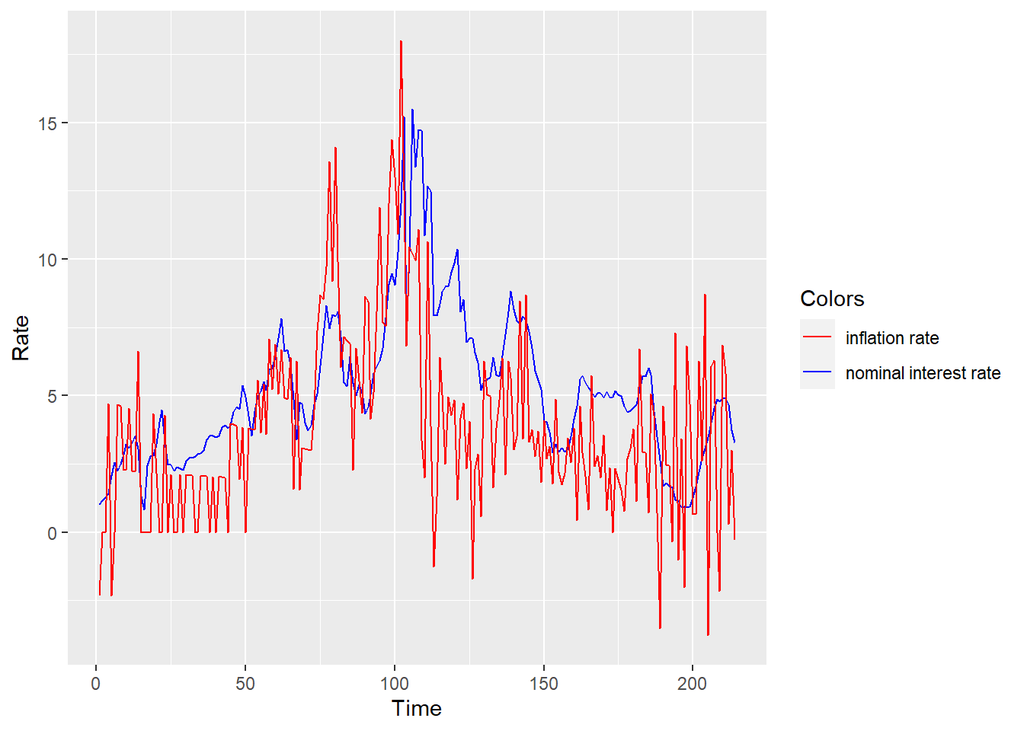

```r
#Plot nominal interest rates and inflation rates
fisher_plot <- ggplot(fisher_data,aes(x=1:nrow(fisher_data))) + geom_line(aes(y=r, color="nominal interest rate", group=1)) + geom_line(aes(y=ann_inf_rate, color="inflation rate", group=1)) + scale_color_manual(values = c("red", "blue", "green", "yellow", "violet", "orange", "black")) + labs(color="Colors") + xlab('Time') + ylab('Rate')
fisher_plot
```

```r
#Find AIC lag length
VARselect(fisher_data$r)
VARselect(fisher_data$ann_inf_rate)
#DF tests on nominal rate using AIC lag length
DFtest_nominalrate <- ur.df(fisher_data$p, type = "drift", lags=8)
print(summary(DFtest_nominalrate))
DFtest_nominalrate2 <- ur.df(fisher_data$p, type = "trend", lags=8)
print(summary(DFtest_nominalrate2))
#DF tests on inflation rate using AIC lag length
DFtest_inflationrate <- ur.df(fisher_data$ann_inf_rate, type = "drift", lags=7)
print(summary(DFtest_inflationrate))
DFtest_inflationrate2 <- ur.df(fisher_data$ann_inf_rate, type = "trend", lags=7)
print(summary(DFtest_inflationrate2))
```

[output not shown]

## After finding the first difference for the nominal rates and the inflation rate, we again run the DF tests with and without time trends, and are able to easily reject at every rejection level as each of the t-values are very negative. This suggests that the level of integration for each series is 1, which suggests that the nominal rate and the inflation rate can be cointegrated.

```r
#Difference the data and find lag length
r_diff <- diff(fisher_data$r)
ann_inf_rate_diff <- diff(fisher_data$ann_inf_rate)
VARselect(r_diff)
VARselect(ann_inf_rate_diff)

#DF tests on first difference nominal rate using AIC lag length
DFtest_nominalrate_diff <- ur.df(r_diff, type = "drift", lags=8)
print(summary(DFtest_nominalrate_diff))
DFtest_nominalrate_diff2 <- ur.df(r_diff, type = "trend", lags=8)
print(summary(DFtest_nominalrate_diff2))

#DF tests on first difference inflation rate using AIC lag length
DFtest_inflationrate_diff <- ur.df(ann_inf_rate_diff, type = "drift", lags=3)
print(summary(DFtest_inflationrate_diff))
DFtest_inflationrate_diff2 <- ur.df(ann_inf_rate_diff, type = "trend", lags=3)
print(summary(DFtest_inflationrate_diff2))
```

[output not shown]

## The Fisher Hypothesis suggests that real interest rates should be stationary as nominal interest rates reflect the long run movement in the inflation rate. Using a DF test on the real interest rate since September 1954, we can see that the Fisher Hypothesis holds at the 10 percent level, given that the test statistic is lower, so we are able to reject the null hypothesis of non-stationarity. However, we are not able to reject the null hypothesis at the 5 or 1 percent levels, which suggests there is weak evidence that the Fisher Hypothesis is true.

```r
#Finding the real interest rate
fisher_data$real_rate <- fisher_data$r-fisher_data$ann_inf_rate
#Finding the optimal lag length
VARselect(fisher_data$real_rate)
```

[output not shown]

```r
#DF test on real interest rate using AIC lag length
DFtest_realrate <- ur.df(fisher_data$real_rate, type = "drift", lags=4)
print(summary(DFtest_realrate))
```

```
##
## ###############################################
## # Augmented Dickey-Fuller Test Unit Root Test #
## ###############################################
##
## Test regression drift
##
##
## Call:
## lm(formula = z.diff ~ z.lag.1 + 1 + z.diff.lag)
##
## Residuals:
##     Min      1Q  Median      3Q     Max
## -5.8629 -1.4664  0.1972  1.3911  9.1536
##
## Coefficients:
##             Estimate Std. Error t value Pr(>|t|)
## (Intercept)  0.31483    0.20020   1.573 0.117385
## z.lag.1     -0.22470    0.08010  -2.805 0.005516 **
## z.diff.lag1 -0.69306    0.09586  -7.230 9.66e-12 ***
## z.diff.lag2 -0.54090    0.09991  -5.414 1.73e-07 ***
## z.diff.lag3 -0.33189    0.09280  -3.576 0.000435 ***
## z.diff.lag4  0.02083    0.07027   0.296 0.767237
## ---
## Signif. codes:  0 '***' 0.001 '**' 0.01 '*' 0.05 '.' 0.1 ' ' 1
##
## Residual standard error: 2.459 on 203 degrees of freedom
## Multiple R-squared:  0.5004, Adjusted R-squared:  0.4881
## F-statistic: 40.66 on 5 and 203 DF,  p-value: < 2.2e-16
##
##
## Value of test-statistic is: -2.8053 3.9408
##
## Critical values for test statistics:
##       1pct  5pct 10pct
## tau2 -3.46 -2.88 -2.57
## phi1  6.52  4.63  3.81
```